# Literacies: Past, Present, Future

## Past

```
def hello_world():
    print("hello world")
```

```
int main()
{
   printf("Hello, World!");
   return 0;
}
```

Every computer scientist starts their journey through programming in a similar fashion, by creating one of the programs above. This is what's called a "Hello World" program. I always thought that this idea was fascinating. Is the language saying "hello" to the developer for the first time or was this the first time the developer was able to express themselves through the given language? I hold the second to be more true to me. As I've grown as a developer and a scientist, I've quickly realized that programming isn't something to be scared of. It's not something that is overly technical and exists only for the quantitative geniuses of the world. Rather, it's a powerful expression of creative literacy. Programming gives the average person the ability to build the tools of the future and the tools of the present, but that's not the true power of learning how to program. Programming teaches you how to reframe analytical problems as simpler, more creative problems. It's not a skill exclusive to the keyboard, but a skill that allows one to see the world in a different light.

My foray into the programming world began in this same way. Ten years ago, my dad sat me in front of the corporate tutorials page for QAD inc, (his workplace at the time). In front of me, I saw a tutorial explaining the basics of HTML, CSS, JavaScript and the fundamentals of web development. Within the first lesson, I had created my first "Hello World" page. Here's what I would have been looking at:

```
<html>
    <head> Hello World!
    </head>

    <body> Hello World!
    </body>
</html>
```

When I opened this website in the browser, here is what happened:

Hello World!

Understandably, at the time, I wasn't too intrigued by this, but it turned out that every "Hello World" page I would make in my life set me through quite a distinct path in my education. Every time I wrote the words "Hello World", I would be opened to a new area of intrigue. A new way to express my creativity. A new path to learn.

While I found these tutorials technically daunting, I did realize even then that this was the beginning of something new for me. I sat there on my dad's computer for hours at a time. I learned how to style web pages. I learned the fundamentals of web design, but even beyond that, I learned that this was the start of something revolutionary for me. This was the beginning of a new way of thinking.

The *Graffiti Manifesto* depicts graffiti as the "voice of the voiceless" and the "glow of a person's humanity". At this point in my life, I set out to do something quite similar. I set out to express myself through the new tools I had been given. I created a number of websites — nothing that was important to the general population, but something that described how I felt about life, ranging from blogs to simple demonstrations of what I knew. This gave me a medium to allow my inner self to flourish. This is when I first saw the connection between code and myself. Through this experience, my viewpoint toward code and analytical thinking was changed for the first time. I began to realize that code was really just a way to extrapolate my creative literacy and show the world. In this way, code is no different from painting, drawing, or writing.

```python
def hello_world():
    print("Hello World!")
hello_world()
```

```
Hello World!
```

My second "Hello World" came a few years after, in my first computer science class at Berkeley. With this computer science class, came a language called Python, but more importantly, it once again revolutionized my way of thinking about computers and life. For me, taking this class shattered the glass wall that surrounded the field of computer science . I was now able to reframe problems totally unrelated to computer science and think about them in a new way. It gave me the power to think and analyze real questions about the world in ways that made sense to a scientist. In a way, it taught me the art of building questions that answer difficult problems with relative ease. This lends itself well to my other primary fields of study: cognitive science and psychology. For example, social dynamics can be easily modeled with a graph and learning lends itself to reinforcement learning algorithms.

In this way, it seems that this act of reframing a problem to fit within a context of a different field is almost exactly the art of remixing something. *Digital Remix: The Art and Craft of Endless Hybridization* by Colin Lankshear and Michele Knobel define the concept of a "remix" as "the practice of taking cultural artefacts and combining and manipulating them into a new kind of creative blend". It was now possible for me to remix two fields in order to solve problems in either field. Remixing, in this scenario, would be a powerful tool that would allow people with limited domain specific knowledge to assist in solving problems in a given domain.

## Present

```
public class HelloWorld {

    public static void main(String[] args) {
        System.out.println("Hello, World");
    }
}
```

My third and final "Hello World" has led me to where I am today. This happened last semester (Fall 2017), when I was introduced to data structures, algorithms, and Java. This contributed to my computer science literacy two-fold. The first is the way these classes were taught. The lower division computer science classes at Berkeley strongly emphasize social learning. In *Developing Understanding of the Idea of Communities of Learners* by Barbara Rogoff, she brings up the idea of a community of learners, based on the premise of learning as shared endeavors with others. In this scenario, everyone would not have the same role, but everyone would be actively participating. This is quite similar to how the lower division computer science classes are run. Students have their own assignments but are highly encouraged to work with others in order to get the most out of every assignment. In fact, in my lower division classes it was quite rare that I would start any kind of assignment without a group of people around me. This kind of learning ensured that we didn't get "stuck" in a way that is detrimental to learning and allowed people to both struggle, and succeed, as a group.

The second part of my developing literacy is the proper introduction to mathematics in my computer science education. I had always known that math was the basis for computer science, but seeing how everything is related led me to a new level of fascination. Lankshear and Knobel's concept of a "remix" once again applies here. Combining math and computer science to build algorithms and data structures with a mathematical basis inspires a completely new type of programming and thinking. When this comes together with everything I've learned to date, the possibilities truly crescendo in terms of the large scale problems that can be simplified and solved with even just my knowledge as a second year undergraduate student.

For example, it is possible to collect data on social dynamics within a group and visualize it as a graph. This graph can then be used to to find cycles within the graph, which would represent certain cliques or groupings of friends within the group. It would then be simple to see which factors correlate to the beginnings of cliques. While this may not capture the entirety of social dynamics, it does provide good insight toward the field. Another example is one project I'm pursuing right now. In an attempt to create a metric for measuring the quality of open data, I am looking at methods of measuring accessibility of open data platforms on the local city scale. At first glance, this seemed like quite a difficult task to accomplish, as this was a fairly qualitative measure. However, I found that it was possible to treat a local city government website as a graph. From there, it is much simpler to see which subset of the graph the open data protocol falls on. Now, the connections to that subset simply have to be measured and that could be part of an accessibility metric.

The cumulation of my knowledge from the past years has truly allowed me to think, program, and solve problems in new, powerful ways. It gave me the ability to combine two fairly technical fields with basically any non-technical field, giving both fields a new outlook. This type of thinking is what inspired me to study both cognitive science and applied math. Studying this combination gives me the potential to make the connections between these fields on a day to day basis. It gives me the inspiration to tackle difficult problems head on.

## Future

```python
import networkx as nx
import matplotlib as plt
```

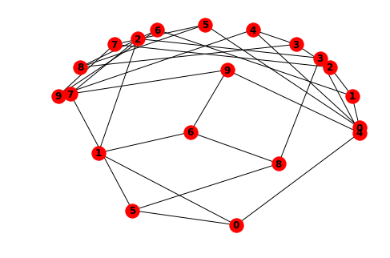

```python
G = nx.petersen_graph()
nx.draw(G, with_labels=True, font_weight='bold')
nx.draw_shell(G, nlist=[range(0, 20), range(20)], with_labels=True, font_weight='bold')
```

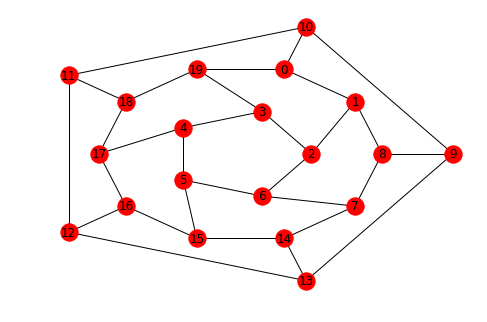

```python
G = nx.dodecahedral_graph()
shells = [[2, 3, 4, 5, 6], [8, 1, 0, 19, 18, 17, 16, 15, 14, 7], [9, 10, 11, 12, 13]]
nx.draw_shell(G, nlist=shells, with_labels = True)
```

### Short Term Future

Doing my fieldwork in a religious private school in the Fruitvale district of Oakland has certainly provided me a lot of experience with the social dynamics of kids and how social learning plays a role in education effectiveness. For example, it is very clear that the kids who work together and enjoy doing schoolwork with their friends tend to finish faster and learn more in the process. It's also interesting to note how the interplay between students influences this. For example, some of the students seclude themselves, but some are quite social. Still others try to be social, but are cast as outsiders by others. Since there are so few students (~20), it is quite possible to denote the relations that the students share manually, through qualitative evidence. This can then be converted to a graph, similar to those above, which will show how the students are connected and how their social dynamics play out. Then, if we look at the number of interconnections in a given subsection of the graph, that would allow one to see the "outsiders" and the "cliques", which definitely exist, even in such a small group. With some assistance from the teacher, we can correlate that with the students that finish their work the quickest or score the highest (the names and any other identifiers would be obfuscated). This would be a really intriguing analysis that attempts to take a few quantitative measures and estimate the qualitative data. It seems that through my experience at this school, I will learn a lot about social dynamics and how they develop. Through the combination of this and my quantitative background, I will be able to expound on this education and draw meaningful conclusions that will give me new insights into the literacies within education.

### Long Term Future

Around six years ago, I had a seizure. It was inexplicable. The neuroscientist came to no conclusion. Science had failed me and I was completely and utterly confused and disappointed, so I researched. I researched like my life depended on it. I learned what a seizure was. I learned the possible causes of seizures and other neurological diseases, but I was still lost. I didn't seem to fit in any of the categories for having a seizure. I didn't seem to be at risk. The explanation that "sometimes things just happen and we don't know why" didn't sit well with me. Now, I am filled with a burning motivation to learn why. This singular question has stuck with me over the years and will continue to stick with me over the years, so this is the question I will strive to answer in the future . In my long term future, I hope to utilize the literacies inherent within computer science, math, and neuroscience in order to create a "remix" to even begin to answer this question. In other words, I hope to develop the skills needed for cognitive modeling to try to understand the age-old mystery of the brain and its related diseases.